# Case Study

Ragnar

January 27, 2019

# Data input and discriptive analysis

First thing first is load packages

```r
# set working directory
setwd("C:/Users/ragna/OneDrive/Documents/ISEG/Actuarial Science Courses @ ISEG/case study")

# load packages

# includes ggplot and dplyr which are good packages when working with data and plot
require(tidyverse)
# For excel reading
require(readxl)

# Pakacage used if we need to plot discriptive plot regarding correlations etc. extension of ggplot
require(GGally)

# packake which includes the melt function which is nice when we need to plot many variables on the same plot
require(reshape2)
```

Next we read the data and modify it a little bit

```r
# read data, skip = Minimum number of rows to skip before reading anything, be it column names or data
autoclaims <- read_excel("2019-student-research-case-study-data.xlsx", skip = 9)
head(autoclaims)
```

```
## # A tibble: 6 x 15
##    Year   Qtr `Risk Class` Type  `Car-years of E~ `Bodily Injury`
##   <dbl> <dbl> <chr>        <chr>            <dbl>           <dbl>
## 1  2009     1 SML          Pers~            15036              95
## 2  2009     1 LSL          Pers~             4563              21
## 3  2009     1 MYA          Pers~             4322              82
## 4  2009     1 SMA          Pers~            16801              96
## 5  2009     1 MSL          Pers~            13979             151
## 6  2009     1 LYL          Pers~             3136              63
## # ... with 9 more variables: `Property Damage` <dbl>, Comprehensive <dbl>,
## #   Collision <dbl>, `Personal Injury` <dbl>, `Bodily Injury__1` <dbl>,
## #   `Property Damage__1` <dbl>, Comprehensive__1 <dbl>,
## #   Collision__1 <dbl>, `Personal Injury__1` <dbl>
```

```r
dimension <- dim(autoclaims)
dimension
```

```
## [1] 2160   15
```

```r
names(autoclaims)
```

```
##  [1] "Year"                  "Qtr"
##  [3] "Risk Class"            "Type"
##  [5] "Car-years of Exposure" "Bodily Injury"
##  [7] "Property Damage"       "Comprehensive"
##  [9] "Collision"             "Personal Injury"
## [11] "Bodily Injury__1"      "Property Damage__1"
## [13] "Comprehensive__1"      "Collision__1"
## [15] "Personal Injury__1"
```

```r
# We need to Change the names

# temporary names vector
tmp <- c("Year", "Qtr", "RiskClass", "Type", "CarYearsOfExposure", "NoBodilyInjury", "NoPropertyDamage",
         "NoComprehensive", "NoCollision", "NoPersonalInjury", "AmountBodilyInjury", "AmountPropertyDamage",
         "AmountComprehensive", "AmountCollision", "AmountPersonalInjury")

variables <- c("CarYearsOfExposure", "NoBodilyInjury", "NoPropertyDamage",
"NoComprehensive", "NoCollision", "NoPersonalInjury", "AmountBodilyInjury", "AmountPropertyDamage",
"AmountComprehensive", "AmountCollision", "AmountPersonalInjury")
names(autoclaims) <- tmp
head(autoclaims)
```

```
## # A tibble: 6 x 15
##    Year   Qtr RiskClass Type  CarYearsOfExpos~ NoBodilyInjury
##   <dbl> <dbl> <chr>     <chr>            <dbl>          <dbl>
## 1  2009     1 SML       Pers~            15036             95
## 2  2009     1 LSL       Pers~             4563             21
## 3  2009     1 MYA       Pers~             4322             82
## 4  2009     1 SMA       Pers~            16801             96
## 5  2009     1 MSL       Pers~            13979            151
## 6  2009     1 LYL       Pers~             3136             63
## # ... with 9 more variables: NoPropertyDamage <dbl>,
## #   NoComprehensive <dbl>, NoCollision <dbl>, NoPersonalInjury <dbl>,
## #   AmountBodilyInjury <dbl>, AmountPropertyDamage <dbl>,
## #   AmountComprehensive <dbl>, AmountCollision <dbl>,
## #   AmountPersonalInjury <dbl>
```

```r
# Add one colum which is the year + qtr
autoclaims$YearQtr <- autoclaims$Year + 2.5*autoclaims$Qtr/10

# Total Exposure for each qtr
autoclaims$TotalExposure <- 0

# let's just do a brute force for loop
for( i in levels(factor(autoclaims$Year))){
  for(j in levels(factor(autoclaims$Qtr))){

    autoclaims$TotalExposure[autoclaims$Year == i & autoclaims$Qtr == j] <- sum(autoclaims$CarYearsOfExposure[autoclaims$Year == i & autoclaims$Qtr == j] )

  }
}

# then we normalize
autoclaims$ExposureNormalize <- autoclaims$CarYearsOfExposure/autoclaims$TotalExposure
```

Next step is to make plots

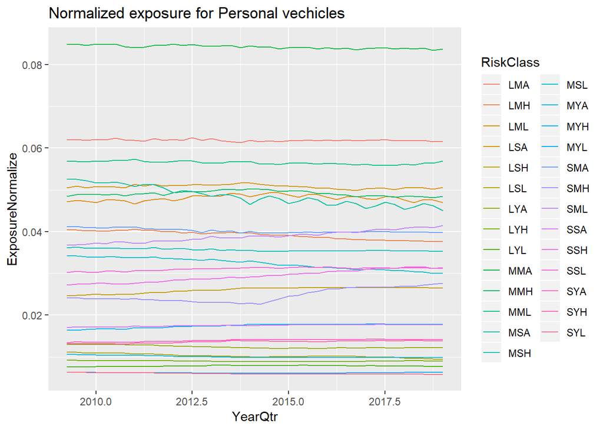

```r
ggplot(data = autoclaims[ autoclaims$Type  == "Personal", , drop = F]) + geom_line(aes( x = YearQtr, y = ExposureNormalize , color = RiskClass)) + ggtitle("Normalized exposure for Personal vechicles")
```

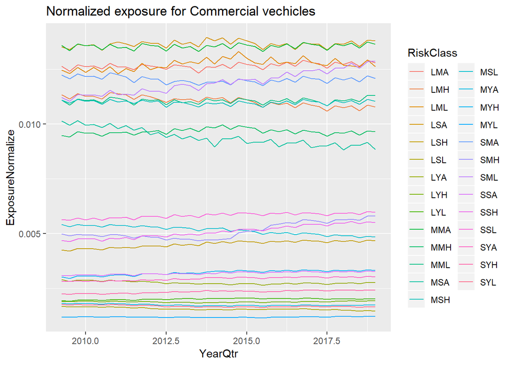

```r
ggplot(data = autoclaims[ autoclaims$Type  == "Commercial", , drop = F]) + geom_line(aes( x = YearQtr, y = ExposureNormalize , color = RiskClass)) + ggtitle("Normalized exposure for Commercial vechicles")
```

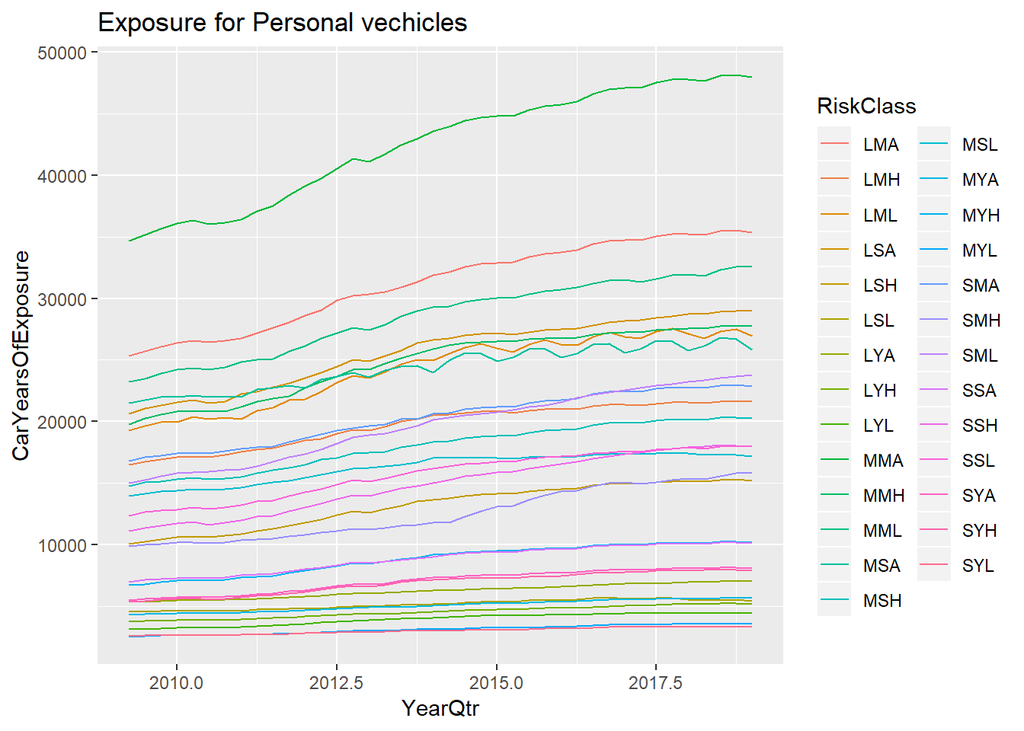

```r
ggplot(data = autoclaims[ autoclaims$Type  == "Personal", , drop = F]) + geom_line(aes( x = YearQtr, y = CarYearsOfExposure , color = RiskClass)) + ggtitle("Exposure for Personal vechicles")
```

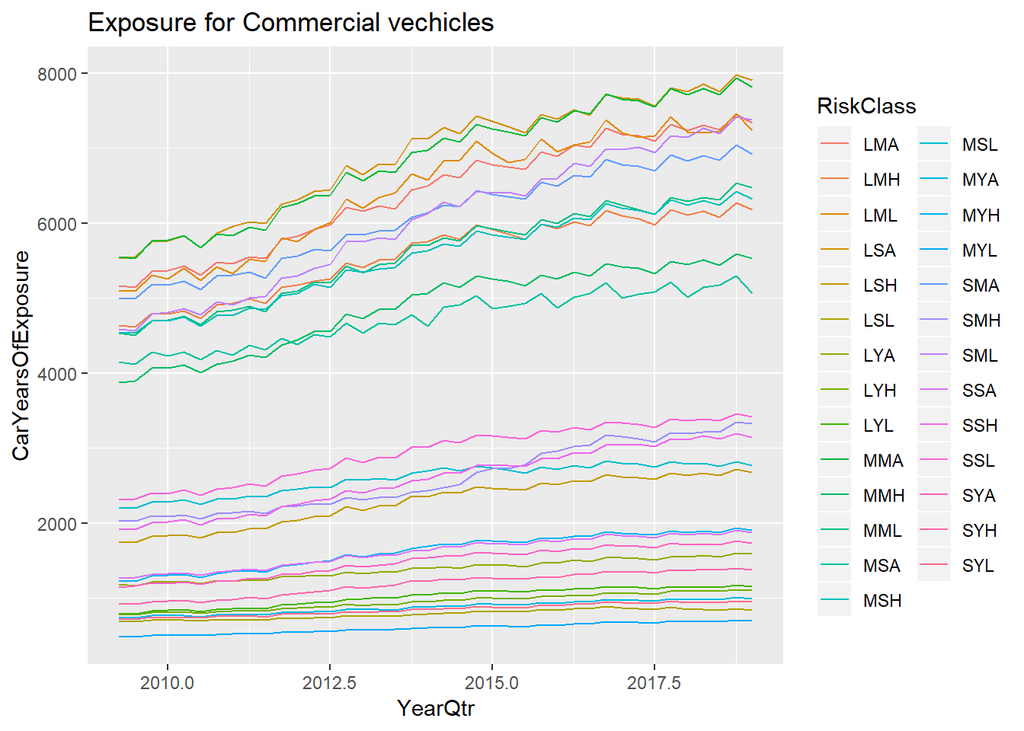

```r
ggplot(data = autoclaims[ autoclaims$Type  == "Commercial", , drop = F]) + geom_line(aes( x = YearQtr, y = CarYearsOfExposure , color = RiskClass)) + ggtitle("Exposure for Commercial vechicles")
```

The following shows exposure and normalized exposure for each risk class for each type. Next We look at all the variables.

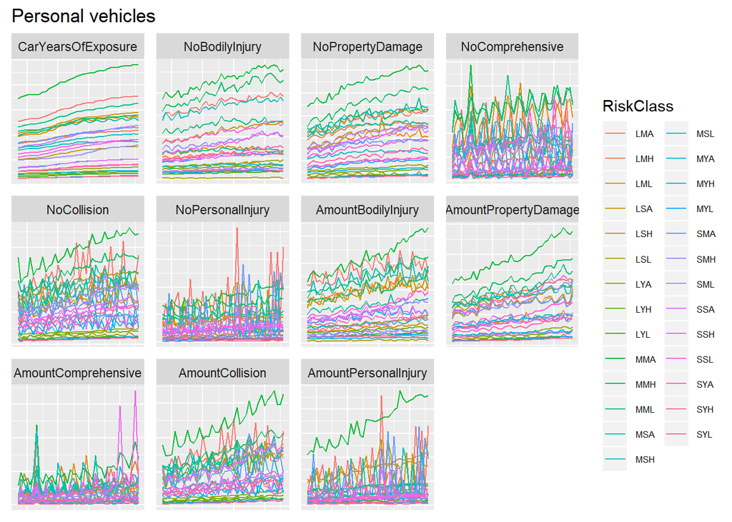

```r
# We need to  use the melt function if we want to plot for each variable
melt.autoclaims <- melt(autoclaims, id = c("Year", "Qtr", "YearQtr", "Type", "RiskClass"))
  ggplot(data = melt.autoclaims[ melt.autoclaims$Type  == "Personal" & !(melt.autoclaims$variable %in% c("TotalExposure", "ExposureNormalize"))
                                 ,  , drop = F]) + geom_line(aes( x = YearQtr, y = value , color = RiskClass))+ facet_wrap( ~ variable, scales = "free") +
    theme(axis.title.x=element_blank(),
          axis.text.x=element_blank(),
          axis.ticks.x=element_blank(),
          axis.title.y=element_blank(),
          axis.text.y=element_blank(),
          axis.ticks.y=element_blank(),
          legend.text=element_text(size=6)) +
    guides(col = guide_legend(nCOL = 1, byrow = F)) + ggtitle("Personal vehicles")
```

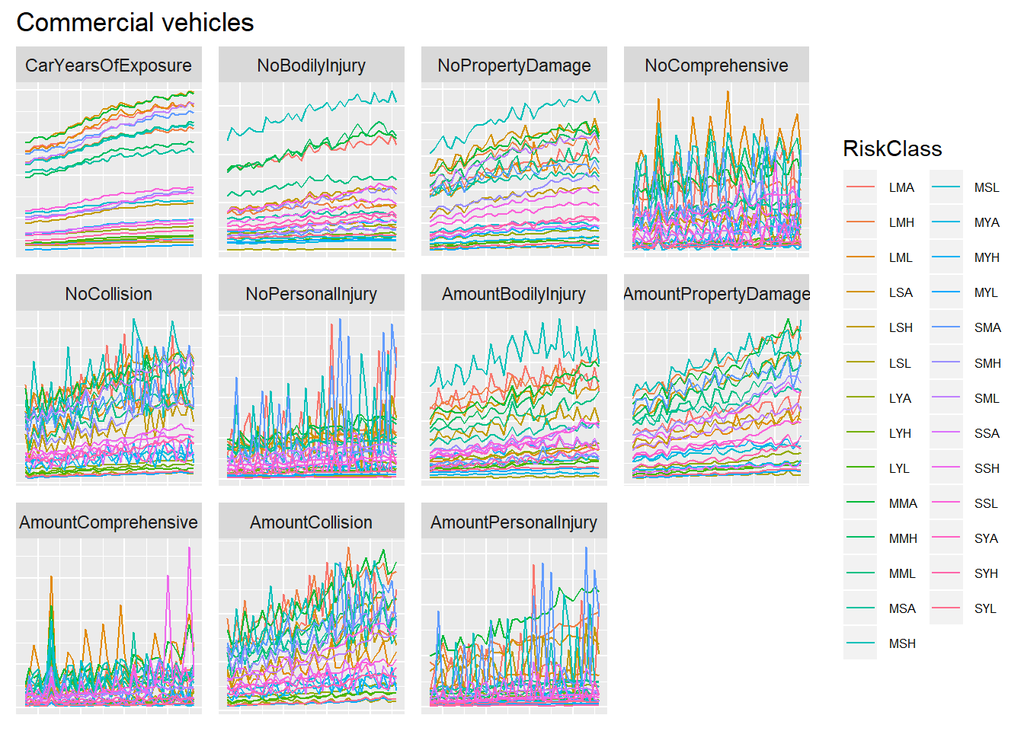

```r
  ggplot(data = melt.autoclaims[ melt.autoclaims$Type  == "Commercial" & !(melt.autoclaims$variable %in% c("TotalExposure", "ExposureNormalize"))
                                 ,  , drop = F]) + geom_line(aes( x = YearQtr, y = value , color = RiskClass))+ facet_wrap( ~ variable, scales = "free") +
    theme(axis.title.x=element_blank(),
          axis.text.x=element_blank(),
          axis.ticks.x=element_blank(),
          axis.title.y=element_blank(),
          axis.text.y=element_blank(),
          axis.ticks.y=element_blank(),
          legend.text=element_text(size=6)) +
    guides(col = guide_legend(nCOL = 1, byrow = F))+ ggtitle("Commercial vehicles")
```

There are seasonal trends but There are large spikes in Amount Comprehensive. One where all risk groups spike but also two large spikes for one Risk group (SSH). Also, the risk group for commerical and Personal don’t necessarily have the same relative sizes of the risk groups that is probably because the number of policyholders in each group is not the same. We need to look closer to the individual variables

## Amount Comprehensive

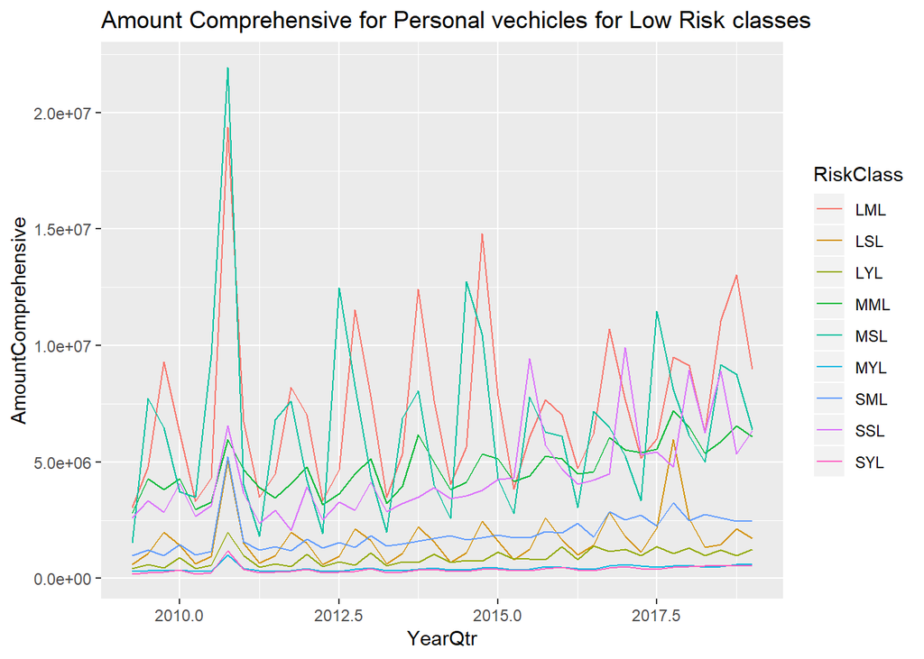

```r
ggplot(data = autoclaims[ grepl("L$", x = autoclaims$RiskClass) & autoclaims$Type  == "Personal", , drop = F]) + geom_line(aes( x = YearQtr, y = AmountComprehensive , color = RiskClass)) + ggtitle("Amount Comprehensive for Personal vechicles for Low Risk classes")
```

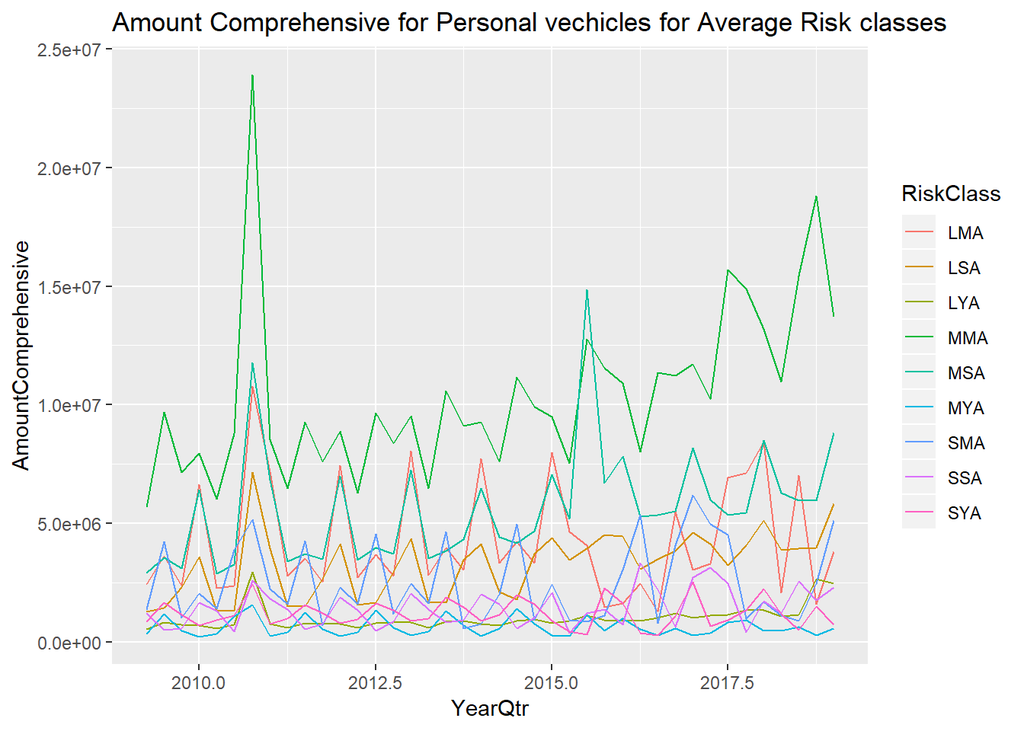

```r
ggplot(data = autoclaims[ grepl("A$", x = autoclaims$RiskClass) & autoclaims$Type  == "Personal", , drop = F]) + geom_line(aes( x = YearQtr, y = AmountComprehensive , color = RiskClass)) + ggtitle("Amount Comprehensive for Personal vechicles for Average Risk classes")
```

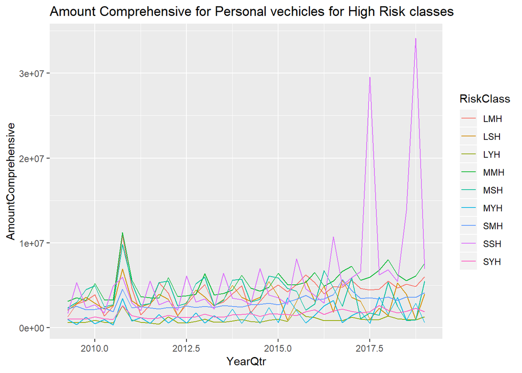

```r
ggplot(data = autoclaims[ grepl("H$", x = autoclaims$RiskClass) & autoclaims$Type  == "Personal", , drop = F]) + geom_line(aes( x = YearQtr, y = AmountComprehensive , color = RiskClass)) + ggtitle("Amount Comprehensive for Personal vechicles for High Risk classes")
```

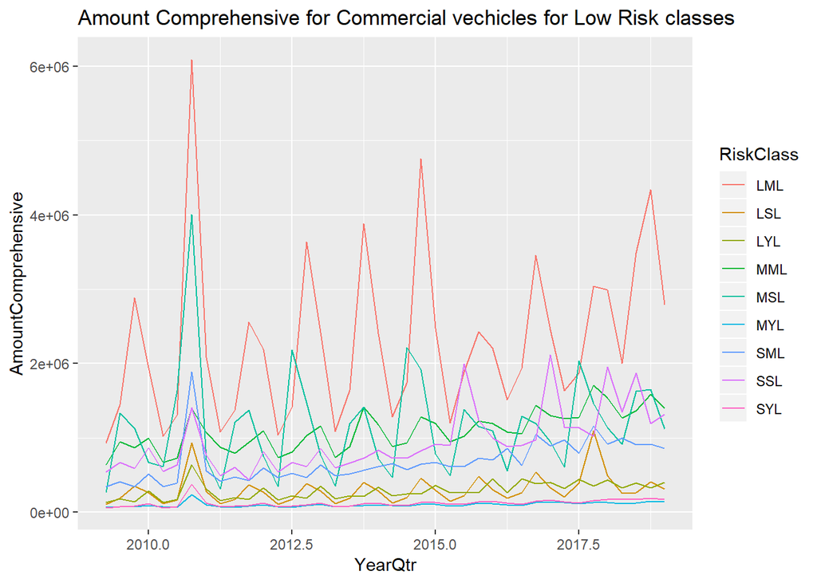

```r
ggplot(data = autoclaims[ grepl("L$", x = autoclaims$RiskClass) & autoclaims$Type  == "Commercial", , drop = F]) + geom_line(aes( x = YearQtr, y = AmountComprehensive , color = RiskClass)) + ggtitle("Amount Comprehensive for Commercial vechicles for Low Risk classes ")
```

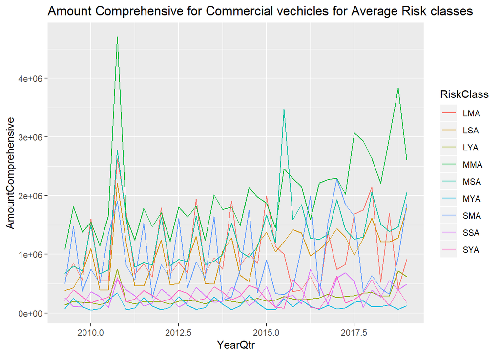

```r
ggplot(data = autoclaims[ grepl("A$", x = autoclaims$RiskClass) & autoclaims$Type  == "Commercial", , drop = F]) + geom_line(aes( x = YearQtr, y = AmountComprehensive , color = RiskClass)) + ggtitle("Amount Comprehensive for Commercial vechicles for Average Risk classes ")
```

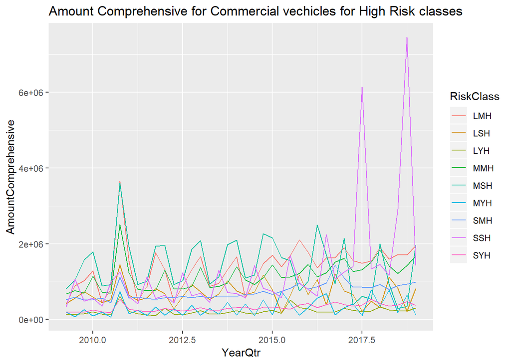

```r
ggplot(data = autoclaims[ grepl("H$", x = autoclaims$RiskClass) & autoclaims$Type  == "Commercial", , drop = F]) + geom_line(aes( x = YearQtr, y = AmountComprehensive , color = RiskClass)) + ggtitle("Amount Comprehensive for Commercial vechicles for High Risk classes")
```

## Number of Comprehensive

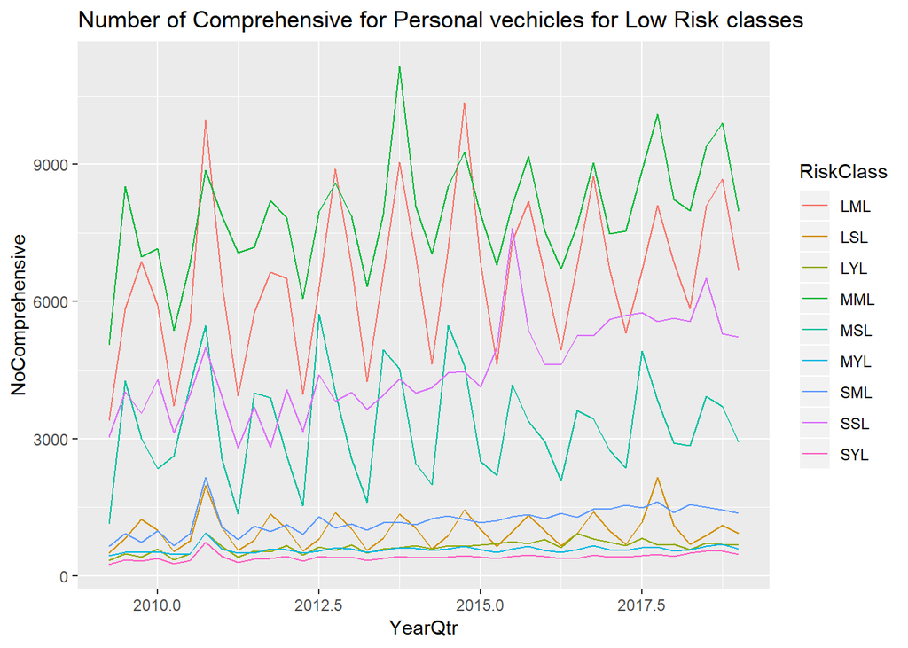

```r
ggplot(data = autoclaims[ grepl("L$", x = autoclaims$RiskClass) & autoclaims$Type  == "Personal", , drop = F]) + geom_line(aes( x = YearQtr, y = NoComprehensive , color = RiskClass)) + ggtitle("Number of Comprehensive for Personal vechicles for Low Risk classes")
```

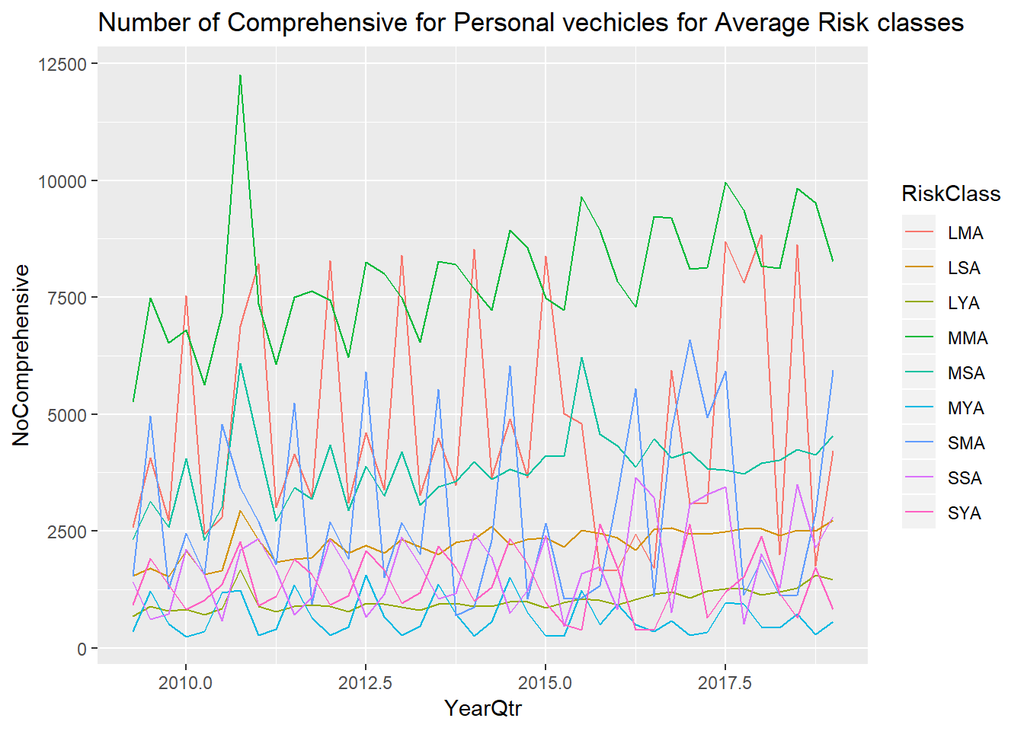

```r
ggplot(data = autoclaims[ grepl("A$", x = autoclaims$RiskClass) & autoclaims$Type  == "Personal", , drop = F]) + geom_line(aes( x = YearQtr, y = NoComprehensive , color = RiskClass)) + ggtitle("Number of Comprehensive for Personal vechicles for Average Risk classes")
```

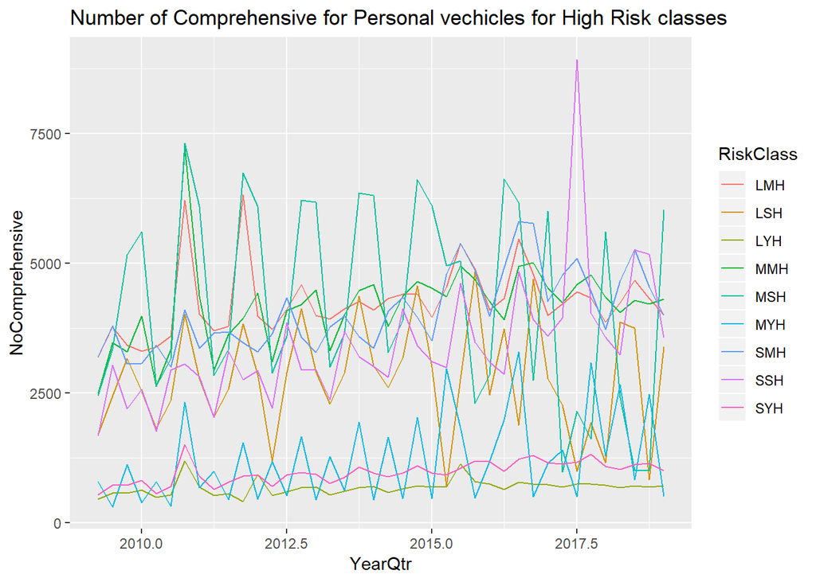

```r
ggplot(data = autoclaims[ grepl("H$", x = autoclaims$RiskClass) & autoclaims$Type  == "Personal", , drop = F]) + geom_line(aes( x = YearQtr, y = NoComprehensive , color = RiskClass)) + ggtitle("Number of Comprehensive for Personal vechicles for High Risk classes")
```

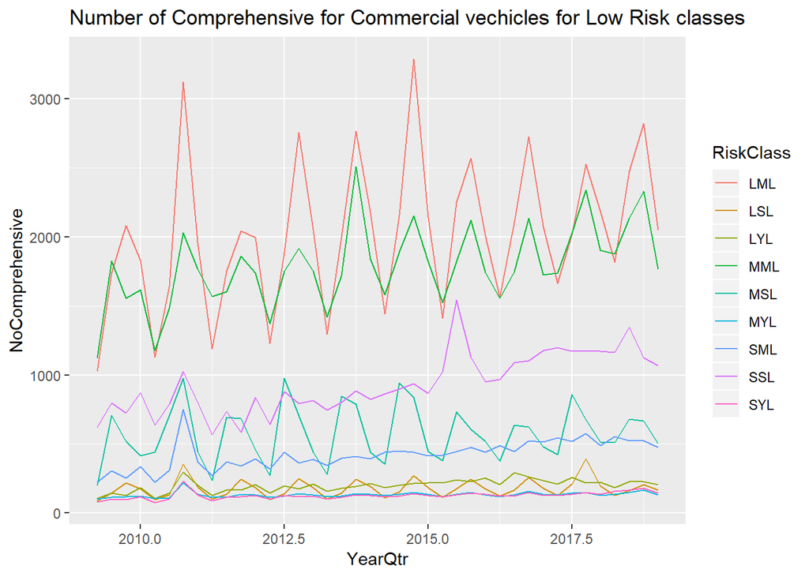

```r
ggplot(data = autoclaims[ grepl("L$", x = autoclaims$RiskClass) & autoclaims$Type  == "Commercial", , drop = F]) + geom_line(aes( x = YearQtr, y = NoComprehensive , color = RiskClass)) + ggtitle("Number of Comprehensive for Commercial vechicles for Low Risk classes ")
```

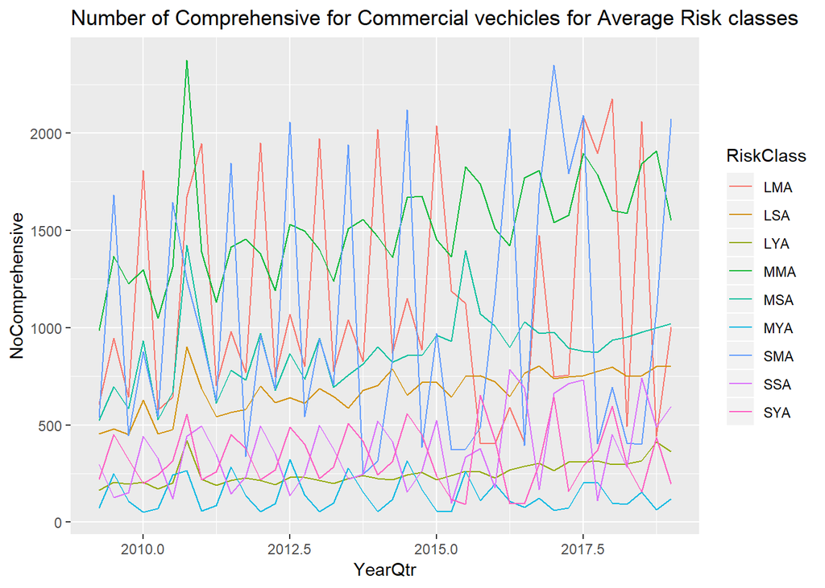

```r
ggplot(data = autoclaims[ grepl("A$", x = autoclaims$RiskClass) & autoclaims$Type  == "Commercial", , drop = F]) + geom_line(aes( x = YearQtr, y = NoComprehensive , color = RiskClass)) + ggtitle("Number of Comprehensive for Commercial vechicles for Average Risk classes ")
```

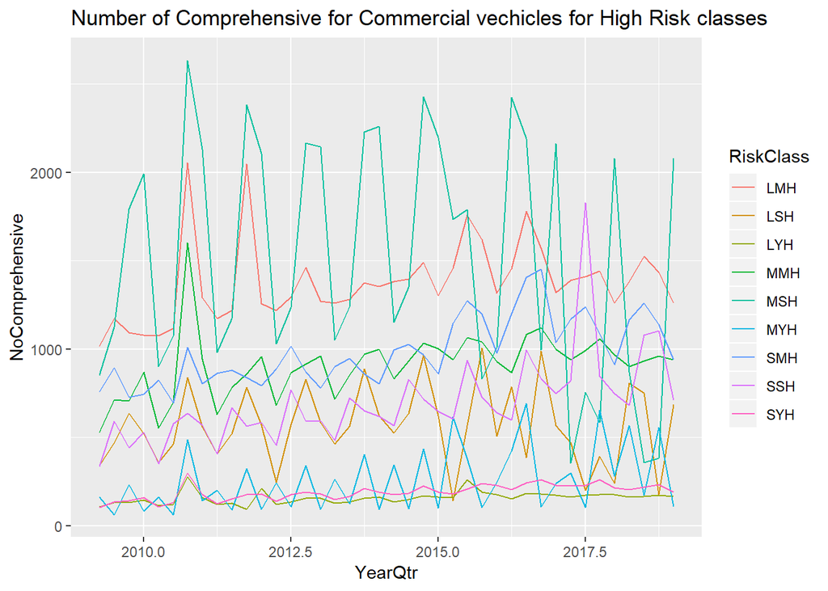

```r
ggplot(data = autoclaims[ grepl("H$", x = autoclaims$RiskClass) & autoclaims$Type  == "Commercial", , drop = F]) + geom_line(aes( x = YearQtr, y = NoComprehensive , color = RiskClass)) + ggtitle("Number of Comprehensive for Commercial vechicles for High Risk classes")
```

## Number of Personal Injury

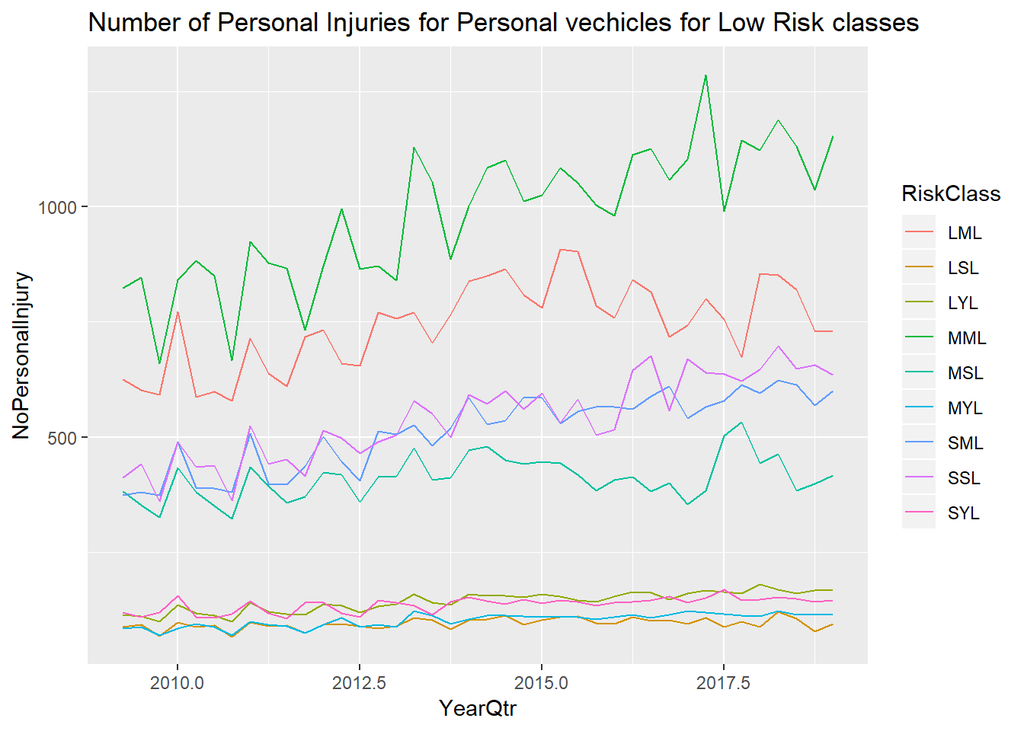

```r
ggplot(data = autoclaims[ grepl("L$", x = autoclaims$RiskClass) & autoclaims$Type  == "Personal", , drop = F]) + geom_line(aes( x = YearQtr, y = NoPersonalInjury , color = RiskClass)) + ggtitle("Number of Personal Injuries for Personal vechicles for Low Risk classes")
```

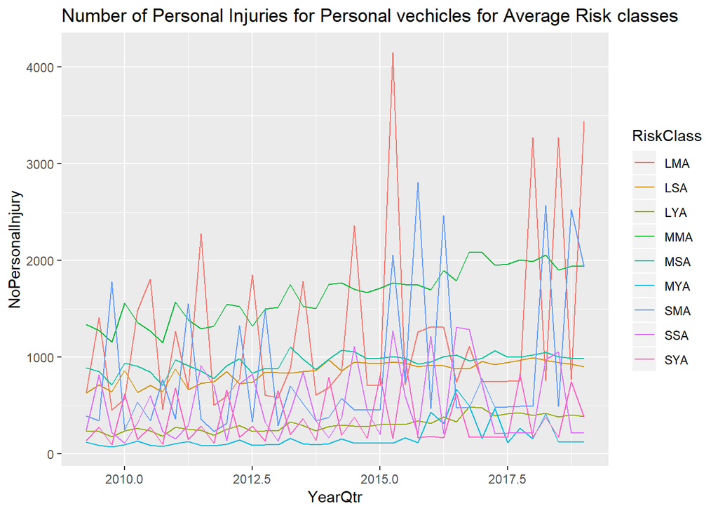

```r
ggplot(data = autoclaims[ grepl("A$", x = autoclaims$RiskClass) & autoclaims$Type  == "Personal", , drop = F]) + geom_line(aes( x = YearQtr, y = NoPersonalInjury , color = RiskClass)) + ggtitle("Number of Personal Injuries for Personal vechicles for Average Risk classes")
```

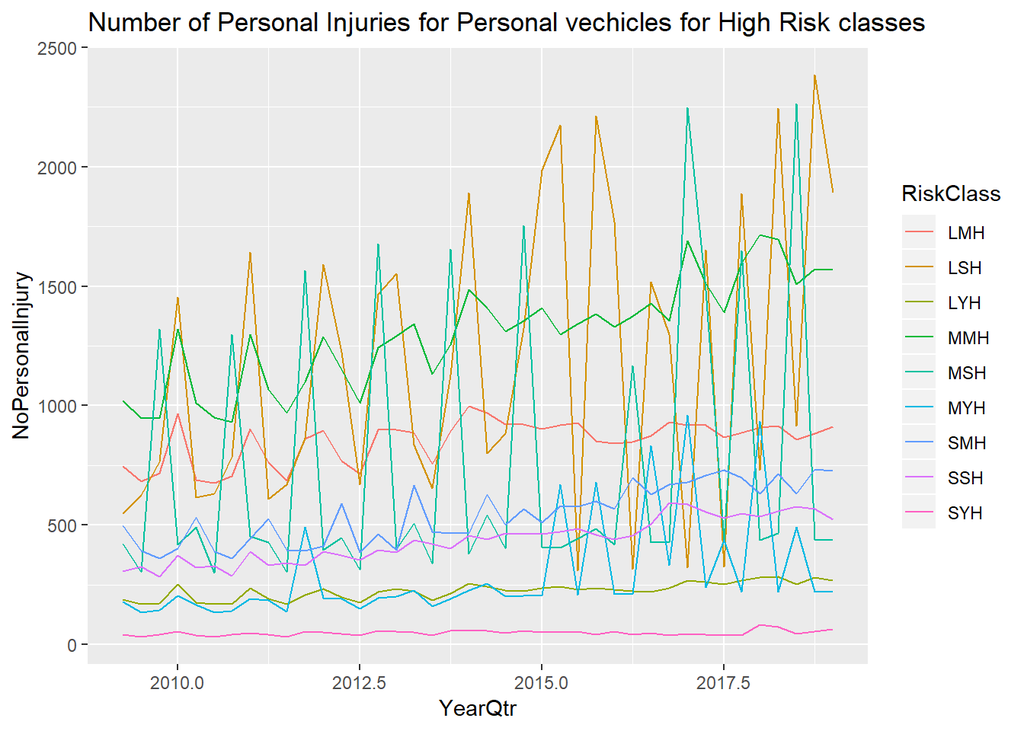

```r
ggplot(data = autoclaims[ grepl("H$", x = autoclaims$RiskClass) & autoclaims$Type  == "Personal", , drop = F]) + geom_line(aes( x = YearQtr, y = NoPersonalInjury , color = RiskClass)) + ggtitle("Number of Personal Injuries for Personal vechicles for High Risk classes")
```

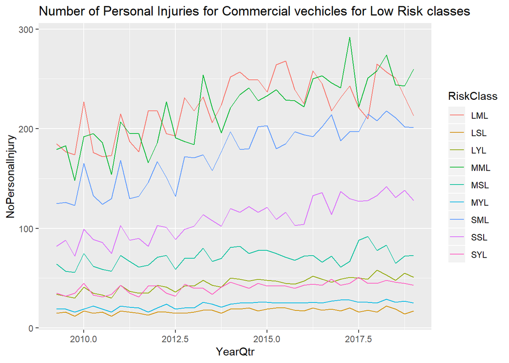

```r
ggplot(data = autoclaims[ grepl("L$", x = autoclaims$RiskClass) & autoclaims$Type  == "Commercial", , drop = F]) + geom_line(aes( x = YearQtr, y = NoPersonalInjury , color = RiskClass)) + ggtitle("Number of Personal Injuries for Commercial vechicles for Low Risk classes ")
```

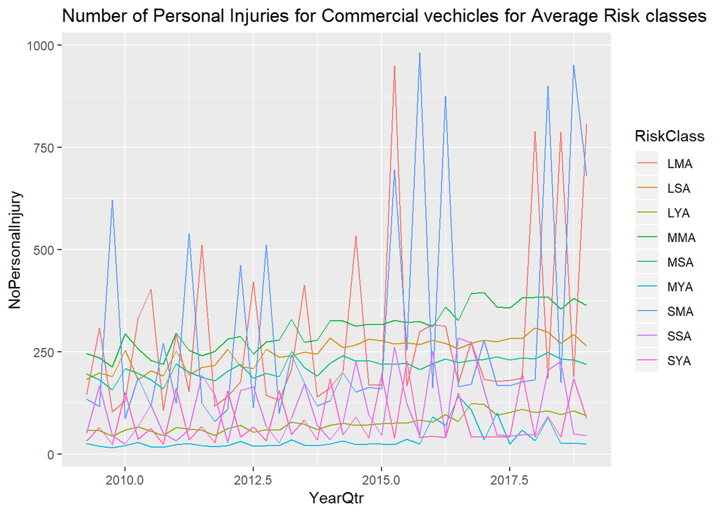

```r
ggplot(data = autoclaims[ grepl("A$", x = autoclaims$RiskClass) & autoclaims$Type  == "Commercial", , drop = F]) + geom_line(aes( x = YearQtr, y = NoPersonalInjury , color = RiskClass)) + ggtitle("Number of Personal Injuries for Commercial vechicles for Average Risk classes ")
```

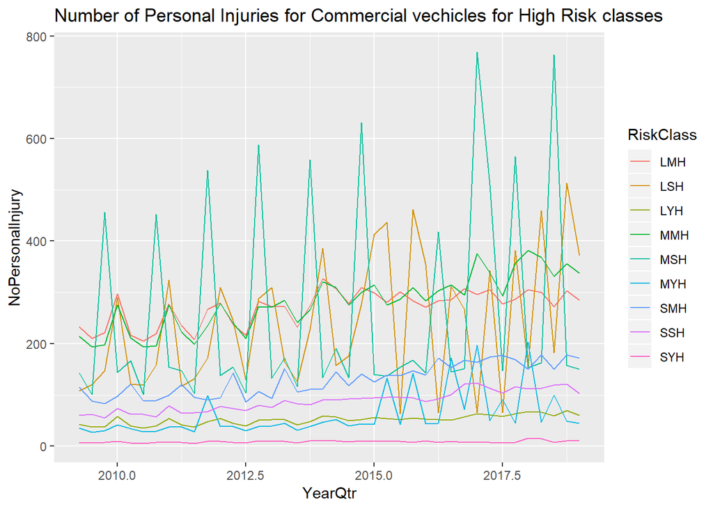

```r
ggplot(data = autoclaims[ grepl("H$", x = autoclaims$RiskClass) & autoclaims$Type  == "Commercial", , drop = F]) + geom_line(aes( x = YearQtr, y = NoPersonalInjury , color = RiskClass)) + ggtitle("Number of Personal Injuries for Commercial vechicles for High Risk classes")
```

Again Super spikes for some High Risk classes, some for average and “normal” for low risk

## Amount Personal injury

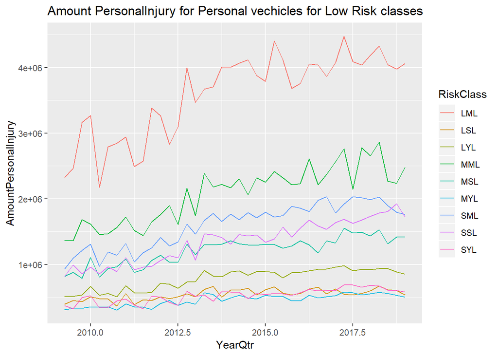

```r
ggplot(data = autoclaims[ grepl("L$", x = autoclaims$RiskClass) & autoclaims$Type  == "Personal", , drop = F]) + geom_line(aes( x = YearQtr, y = AmountPersonalInjury , color = RiskClass)) + ggtitle("Amount PersonalInjury for Personal vechicles for Low Risk classes")
```

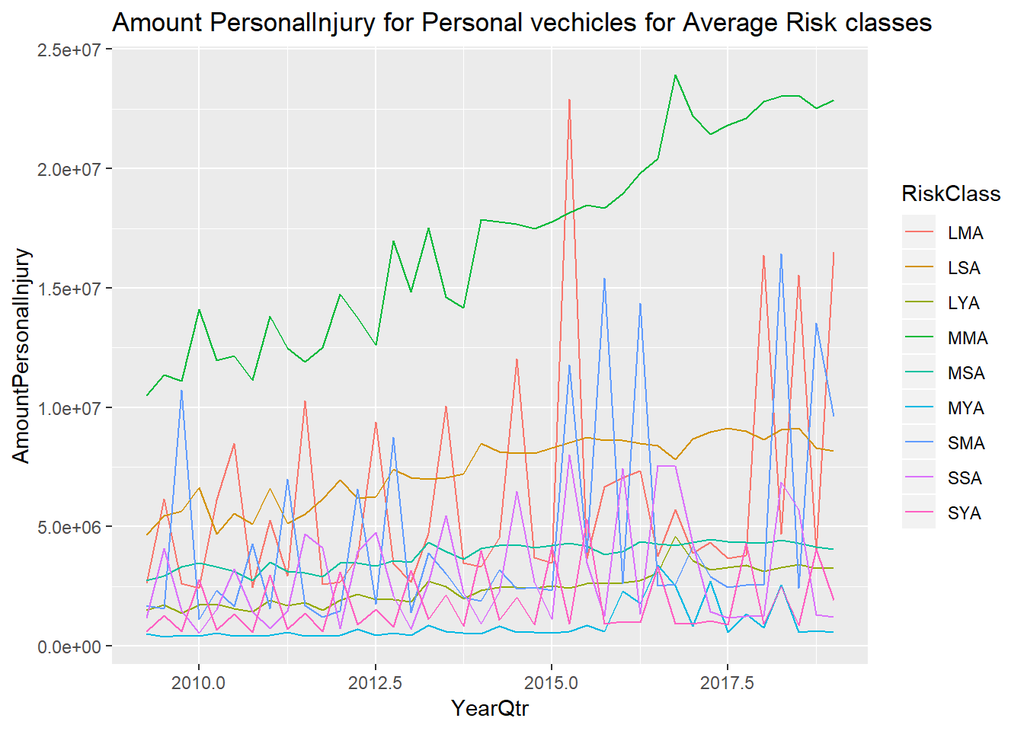

```r
ggplot(data = autoclaims[ grepl("A$", x = autoclaims$RiskClass) & autoclaims$Type  == "Personal", , drop = F]) + geom_line(aes( x = YearQtr, y = AmountPersonalInjury , color = RiskClass)) + ggtitle("Amount PersonalInjury for Personal vechicles for Average Risk classes")
```

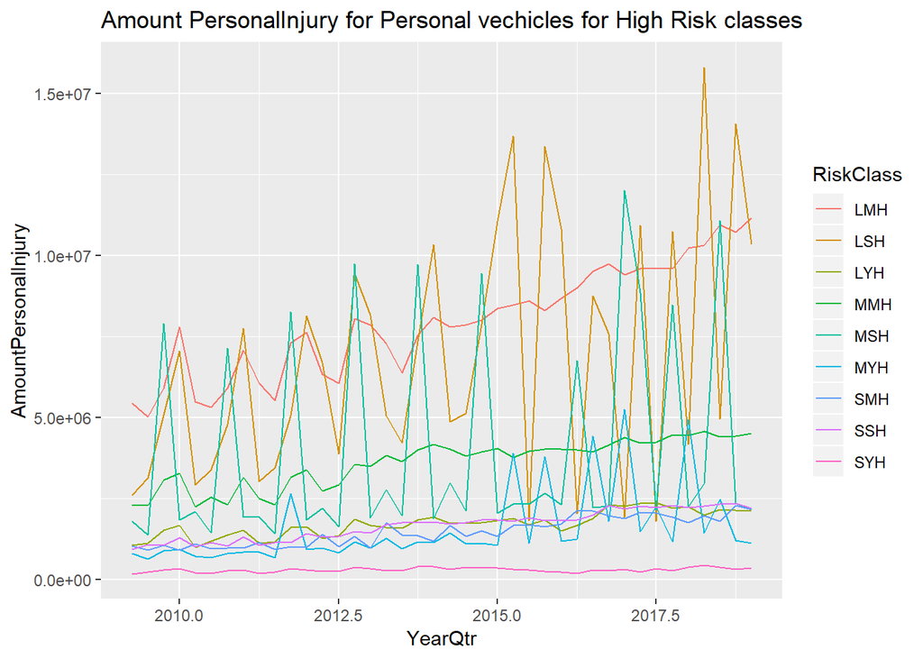

```r
ggplot(data = autoclaims[ grepl("H$", x = autoclaims$RiskClass) & autoclaims$Type  == "Personal", , drop = F]) + geom_line(aes( x = YearQtr, y = AmountPersonalInjury , color = RiskClass)) + ggtitle("Amount PersonalInjury for Personal vechicles for High Risk classes")
```

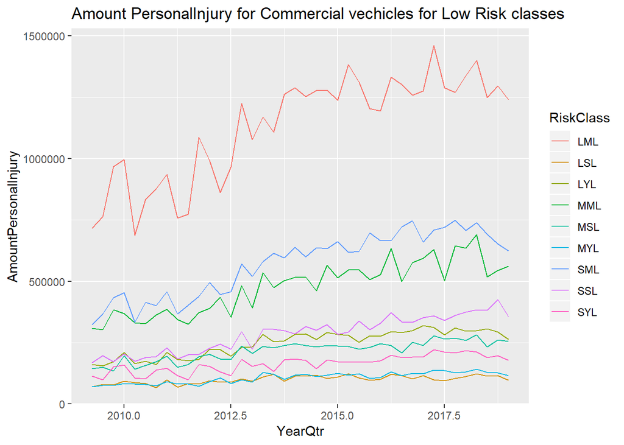

```r
ggplot(data = autoclaims[ grepl("L$", x = autoclaims$RiskClass) & autoclaims$Type  == "Commercial", , drop = F]) + geom_line(aes( x = YearQtr, y = AmountPersonalInjury , color = RiskClass)) + ggtitle("Amount PersonalInjury for Commercial vechicles for Low Risk classes ")
```

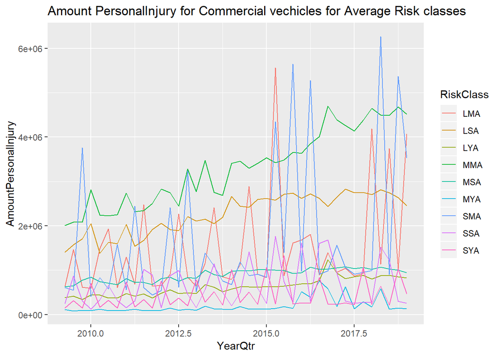

```r
ggplot(data = autoclaims[ grepl("A$", x = autoclaims$RiskClass) & autoclaims$Type  == "Commercial", , drop = F]) + geom_line(aes( x = YearQtr, y = AmountPersonalInjury , color = RiskClass)) + ggtitle("Amount PersonalInjury for Commercial vechicles for Average Risk classes ")
```

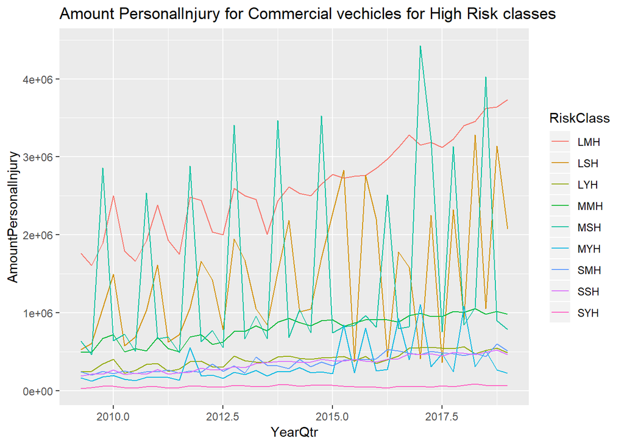

```r
ggplot(data = autoclaims[ grepl("H$", x = autoclaims$RiskClass) & autoclaims$Type  == "Commercial", , drop = F]) + geom_line(aes( x = YearQtr, y = AmountPersonalInjury , color = RiskClass)) + ggtitle("Amount PersonalInjury for Commercial vechicles for High Risk classes")
```

The low risk class has small oscilation but can be large for the other two